# Statistical Modelling Assignment 1

Akshat Dwivedi

12-04-2016

# Question 1

As an initial step, we fit a GLM model to the motorins data from the package `faraway` with `perd` (payment per claim) as the response variable, all the covariates (except payment and claim since perd is a ratio of these two variables), and assuming a Gamma distribution for the response variable with the *inverse* link function as an initial step. The inverse link function is the default link function for Gamma regression models. The table below shows the (spearman) correlation between the continuous variables in the motorins data. This was chosen over the pearson correlation due to the presence of extreme outliers and rejection of the multivariate normality assumption for pairs of variables using Mardia’s Multivariate Normality Test.

```
##           Insured    Claims   Payment
## Insured 1.0000000 0.9172669 0.8680409
## Claims  0.9172669 1.0000000 0.9330825
## Payment 0.8680409 0.9330825 1.0000000
```

This shows that the variables are highly correlated with each other indicating multicollinearity. Including claims, payment and insurance in the model together will lead to inflated std errors of the estimated regression coefficients. This can be measured by looking at the next two tables which show VIF and the square root of the VIF which shows how high the standard errors of the coefficients are compared to a model with uncorrelated predictors.

```
##   Insured    Claims   Payment
##  6.350043 12.100753  7.786612
```

And the square root given by

```
##  Insured   Claims  Payment
## 2.519929 3.478614 2.790450
```

Based on this, we drop Claims from the models that will be fit to the data and decide to keep payment in the model.

We omit the output from the model fit and report that the AIC value for the fitted model is given as 3.38266310^{4}. Next, we select the covariates to be included in the model using the stepwise selection approach combined with Akaike Information Criterion. The following table shows the output from running stepwise selection on the fitted model.

```
## Start:  AIC=33826.63
## perd ~ Kilometres + Zone + Bonus + Make + Insured + Payment
##
##              Df Deviance   AIC
## - Kilometres  4   867.12 33825
## - Bonus       1   863.26 33825
## <none>            862.84 33827
## - Insured     1   865.32 33828
## - Payment     1   866.29 33830
## - Zone        6   874.06 33832
## - Make        8   883.40 33842
##
## Step:  AIC=33828.21
## perd ~ Zone + Bonus + Make + Insured + Payment
```

```
##
## Call:  glm(formula = perd ~ Zone + Bonus + Make + Insured + Payment,
##     family = Gamma(link = "inverse"), data = motor[, -6])
##
## Coefficients:
## (Intercept)        Zone2        Zone3        Zone4        Zone5
##   2.189e-04    1.580e-05   -1.039e-05   -1.729e-05   -2.799e-05
##       Zone6        Zone7        Bonus        Make2        Make3
##  -2.960e-05   -1.765e-05   -1.664e-06    6.765e-06   -3.236e-05
##       Make4        Make5        Make6        Make7        Make8
##   3.956e-06    1.613e-06   -6.518e-06    1.062e-05   -4.732e-05
##       Make9      Insured      Payment
##   2.218e-05    3.139e-09   -2.103e-11
##
## Degrees of Freedom: 1796 Total (i.e. Null);  1779 Residual
## Null Deviance:       899.4
## Residual Deviance: 867.1     AIC: 33830
```

This shows that dropping Kilometres or Bonus from the main effects model leads to the lowest AIC values of 33825. However, dropping Kilometres from the model in the next step results in a larger AIC value and we decide to keep it in the model.

## (b)

Next, we fit a Gamma model with the log link function. The AIC for the two models are

```
##      df      AIC
## fit1 23 33826.63
## fit2 23 33825.94
```

We see that using the log link leads to a marginal improvement. Howvever, it is observed that running the model with log-link allows us to fit a model with all the covariates (including claims) and, hence we prefer this model over the model with the inverse link.

## (c)

In this part, we perform stepwise selection on the gamma model with the log link function and including all the covariates in the biggest model but using BIC instead of the AIC as was done in part (a).

```
## glm(formula = perd ~ Insured + Claims + Payment, family = Gamma(link = "log"),
##     data = motor)
```

We see that the model with the variables Insured, Claims and Payment resulted in the smallest BIC with a value of 3.374246310^{4}. However, it should be noted that the model did not converge to the final model and the selected model may not necessarily be the best one.

## (d)

We wish to see if the variable claims can be modelled by a Poisson GLM. However, for a Poisson model, the dispersion parameter is set to be 1. Violation of this can lead to what is known as under/over dispersion which means that an unobserved variable, while not impacting the mean of the response Y, does affect the variance of Y. Overdisperson is when the variance of the response Y is larger than what is expected from the Poisson model. Underdispersion is when this conditional variance of Y (on the unobserved variable) is less than what is captured by the model. We can test for under/overdispersion by calculating the ratio of residual deviance to the residual degrees of freedom. This results in 16.9319675 which indicates that there is significant overdispersion in the model. Fitting a quasipoisson model estimates the overdispersion parameter to be 19.76. Another indicator for overdispersion would be to take the ratio Var(Y)/E(Y). If this ratio is significantly larger than 1, then it violates the Poisson assumption that the mean = variance. The var/mean ratio for the Claims variable is 773.4308439 which indicates overdispersion as it is greater than 1.

# Question 2

We consider the US temperature data that are available in the R package SemiPar which has 56 observations on the temperature (minimum average January temperature) and location of 56 US cities (city name, latitude and longitude). The response variable is minimum temperature and latitude and longitude are the two predictor variables.

## (a)

First, we fit the additive model $temp = \beta_0 + \beta_1 * latitude + \beta_2 * longitude + \varepsilon$ to the dataset, followed by an additive model with interaction between the two predictors.

```
##      df      AIC
## mod1  4 380.7272
## mod2  5 369.9616
```

Based on the AIC values of the two models above, we select the model with interaction effect based on the lower AIC score.

## (b)

We use order selection idea to construct a test for additivity. The null hypothesis is chosen as the additive model, i.e., $H_0$: $E(Y) = \beta_0 + \beta_1 x_1 + \beta_2 x_2$ vs more complicated alternative models. For this part, we restrict the maximum order to 3, i.e., the alterantive class contains models with the main effects as well as interaction, quadratic or cubic terms which are added sequentially to the null model. We compare each of these models to the null model using the test statistic $T_n$ = $\text{max}_{m \geq 1} \frac{\text{LRT}(M_m, M_0)}{m} > C_n$. $C_n = 2$ leads to the usual AIC, whereas for other values of $C_n$, it leads to a modified AIC (with penalty constant $C_n \neq 2$). We can select $C_n$ such that $P(T_{OS} \leq C_n) = 1 - \alpha$. For this question, we select $C_n = 4.18$ which corresponds to rejecting the null at $\alpha = 5\%$. The list of models that were tried are given below.

```
##          Tn Reject     model_form
## 1  12.76566   TRUE I(x1^1 * x2^1)
## 2   6.45613   TRUE I(x1^2 * x2^0)
## 3  20.92584   TRUE I(x1^0 * x2^2)
## 4  17.48132   TRUE I(x1^2 * x2^1)
## 5  14.01716   TRUE I(x1^1 * x2^2)
## 6  11.70335   TRUE I(x1^2 * x2^2)
## 7  11.45004   TRUE I(x1^3 * x2^0)
## 8  16.86748   TRUE I(x1^0 * x2^3)
## 9  15.12424   TRUE I(x1^3 * x2^1)
## 10 14.08237   TRUE I(x1^1 * x2^3)
## 11 12.80259   TRUE I(x1^3 * x2^2)
## 12 12.10287   TRUE I(x1^2 * x2^3)
## 13 11.22453   TRUE I(x1^3 * x2^3)
```

## (c)

In this part, instead of picking the additive model in the previous part, we pick three different null models with each model containing main effecs, quadratic effects, cubic effects (max order k = 3), quartic effects (max order k = 4) and quintic effects (max order k = 5). So each of the three models is picked as the null model with alternative models same as that in part (b) where all the interaction effects are added sequentially.

# Question 3

**Included separately, attached at the end of this document.**

# Question 4

This question comprises implementing the ridge regression estimator $\hat{\beta}_R = (X^t X + \lambda I_p)^{-1} X^t Y$ in R and using this implementation to estimate the coefficients of the following quadratic additive model
$$dist = \beta_0 + \beta_1 * speed + \beta_2 * speed^2 + \varepsilon$$
and plotting the estimated values of $\beta_2$ vs different values of $\lambda$. The `cars` dataset included in R contains the variables `speed` and `distance`. The funtion that implements the ridge estimator in code is given below.

```r
ridge = function(x, y, lambda) {

  # x : design matrix
  # y : response variable
  # lambda : scalar; lambda parameter in the ridge estimator
  # \beta = [(X^t * X + \lambda * I_p) ^ -1] * (X^t * Y)
  # p = ncol(x) in the above statement

  xt_x = t(x) %*% as.matrix(x)
  lambda_matrix = lambda * diag(x = 1, nrow = ncol(x))
  beta_ridge = solve(xt_x + lambda_matrix) %*% (t(x) %*% y) %>% t() %>% data.frame()
  return(beta_ridge)
}
```

We evaluate the coefficients for $\lambda \in \{0,1,2,3,\ldots,100\}$, i.e. for 100 equally spaced values of lambda starting from 0 and ending on 100. Furthermore, the variables are centered and scaled so the intercept term does not need to be estimated and can be dropped from the model. Thus, only coefficients $\beta_1$ and $\beta_2$ are estimated for the model. The next figure contains the a plot of the $\beta_2$ vs $\lambda$.

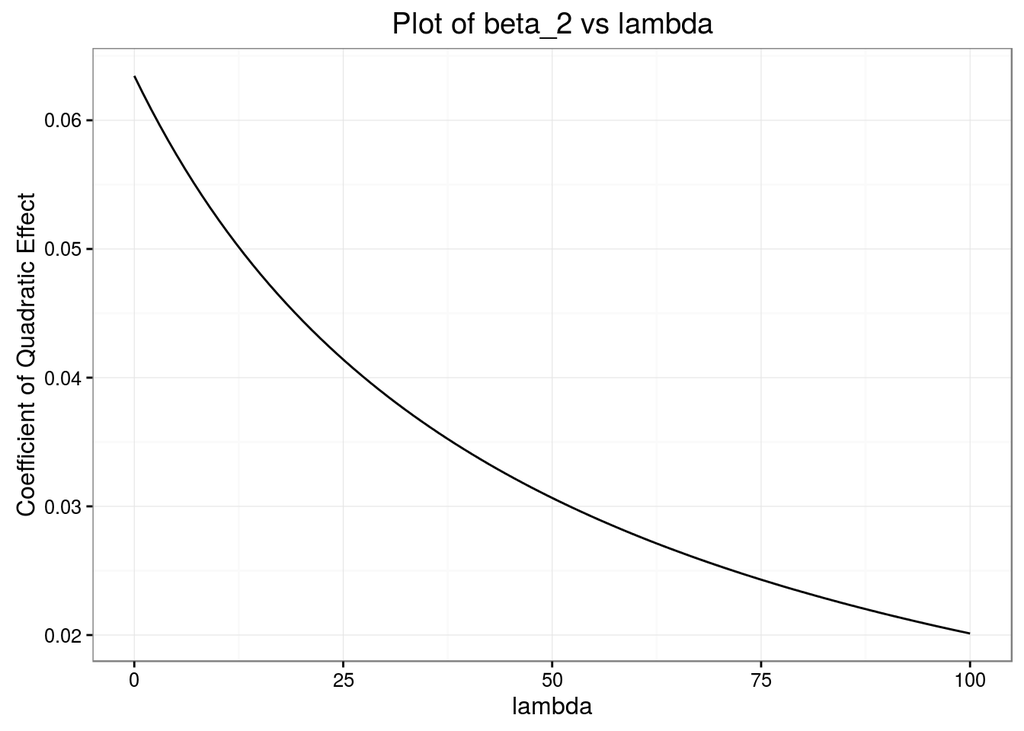

From the plot above, we see that as the value of $\lambda$ increases, the shrinkage of the coefficient(s) tends towards zero, i.e., the coefficients get smaller and smaller. For example, for $\lambda = 0$, $\hat{\beta}_2 \approx 0.06$ whereas $\hat{\beta}_2 = 0.02$ for $\lambda = 100$.

# Appendix (R Code)

```r
## Question 1
library(faraway)
library(ggplot2)
library(dplyr)

motor = motorins
names(motor)

pairs(motor)

## deciding which correlation method to use;
## pearson affected by outliers, spearman
## https://stats.stackexchange.com/questions/3730/pearsons-or-spearmans-correlation-with-non-normal-data/3733#3733
## testing multivariate normality of pairs of variables
MVN::mardiaTest(motor[,5:8], qqplot = TRUE)
MVN::mardiaTest(motor[,5:6], qqplot = TRUE)
MVN::mardiaTest(motor[,6:7], qqplot = TRUE)
MVN::mardiaTest(motor[,7:8], qqplot = TRUE)
MVN::mardiaTest(motor[,c(5,7)], qqplot = TRUE)
MVN::mardiaTest(motor[,c(5,8)], qqplot = TRUE)
MVN::mardiaTest(motor[,c(6,8)], qqplot = TRUE)
MVN::mardiaTest(motor[,5:7], qqplot = TRUE)
## not multivariate normal and plenty of outliers based on the pairs plot: chose spearman

# so we stick with spearman correlation
cor(motor[,5:8], method = "spearman")
cor(motor[,5:7], method = "spearman")
cor(motor[,5:8], method = "pearson")

diag(solve(cor(motor[,c(5,6,7)], method = "spearman"))) # gives us the VIF
diag(solve(cor(motor[,c(5,7)], method = "spearman")))
diag(solve(cor(motor[,c(6,7)], method = "spearman")))
diag(solve(cor(motor[,c(5,6)], method = "spearman")))

sqrt(diag(solve(cor(motor[,c(5,6,7)], method = "spearman")))) # gives us the VIF
sqrt(diag(solve(cor(motor[,c(5,7)], method = "spearman"))))
sqrt(diag(solve(cor(motor[,c(6,7)], method = "spearman"))))
sqrt(diag(solve(cor(motor[,c(5,6)], method = "spearman"))))

fit1 = glm(perd ~ ., family = Gamma(link = "inverse"), data = motor[,-6])
# default link is inverse, others are identity and log; dropping claims and payment
summary(fit1)
par(mfrow = c(2,2))
plot(fit1)
par(mfrow = c(1,1))
drop1(fit1, test = "F")
MASS::stepAIC(fit1, k = 2, scope = list(upper = ~., lower = ~1) , direction = "both")
anova(fit1, test = "Chisq")
summary(update(fit1, . ~ . - Kilometres))
AIC(fit1)

## Different link functions

fit2 = update(fit1, family = Gamma(link = "log"))
summary(fit2)
par(mfrow = c(2,2))
plot(fit2)
par(mfrow = c(1,1))
drop1(fit2, test = "F")
MASS::stepAIC(fit2, k = 2, scope = list(upper = ~., lower = ~1), direction = "both")
anova(fit2, test = "Chisq")
AIC(fit2)

## using BIC instead of AIC
BIC(fit1) # inverse link
BIC(fit2) # log link
MASS::stepAIC(fit1, k = log(nrow(motor)), scope = list(upper = ~., lower = ~1) , direction = "both")
MASS::stepAIC(fit2, k = log(nrow(motor)), scope = list(upper = ~., lower = ~1), direction = "both")

## checking overdispersion for claims
fit = glm(Claims ~ ., family = "poisson", data = motor[,-8])
summary(fit)
par(mfrow = c(2,2))
plot(fit)
par(mfrow = c(1,1))
fit$deviance/fit$df.residual
var(motor$Claims)/mean(motor$Claims)
summary(update(fit, . ~ . , family = quasipoisson))

## Question 2
## (a)
library(SemiPar)
data(ustemp)

mod1 = glm(min.temp ~ latitude + longitude, family = "gaussian", data = ustemp)
summary(mod1)
mod2 = update(mod1, . ~ latitude * longitude)
summary(mod2)

AIC(mod1, mod2)

## (b)
## The code for (b) and (c) was written jointly with another student
X = poly(ustemp$latitude, ustemp$longitude)
x1 = X[,1]
x2 = X[,2]
Y  = ustemp$min.temp

pvalue = function(c_n, m = 100) {
  1 - exp((-sum((1 - pchisq((1:m) * c_n, 1:m))/(1:m))))
}
compare_models = function(null_formula, alt_formula, Cn = 4.18){
  null_model = lm(null_formula)
  null_logLik = logLik(null_model)
  altn_model = lm(alt_formula)
  altn_logLik = logLik(altn_model)
  Tn = 2 * (altn_logLik - null_logLik) / (attr(altn_logLik, "df") - attr(null_logLik, "df"))
  reject = Tn > Cn
  out = data.frame(Tn = Tn, Reject = reject)
  return(out)
}
model_list = function(order, interactions = TRUE) {
  model_form = vector()
  k=1
  for(i in 1:order){
    if(interactions == TRUE) {
      for(j in 0:(i-1)){
        model_form[k] = paste("I(x1^",i," * ","x2^", j,")", sep="")
        k=k+1
        model_form[k] = paste("I(x1^",j," * ","x2^", i,")", sep="")
        k=k+1
      }
    }
    model_form[k] = paste("I(x1^",i," * ","x2^", i,")", sep="")
    k=k+1
  }
  return(model_form)
}
order = 3
model_form = model_list(order)
null_model = Y ~ I(x1) + I(x2)

output = sapply(order:length(model_form), function(x){
  compare_models(null_model, paste("Y ~ ", paste(model_form[1:x], collapse = "+")))
})
model_comparison = as.data.frame(t(output))
model_comparison$model_form = model_form[order:length(model_form)]
best_model_idx = which.max(model_comparison$Tn)
best_model = model_comparison[best_model_idx,]
best_formula = paste("Y ~", paste(model_form[1:best_model_idx], collapse = " + ") )
best_p_value = pvalue(unlist(best_model$Tn))

str(model_comparison)

## (c)
k = 5
null_form = model_list(k, interactions = FALSE)
null_model = paste("Y ~ ", paste(null_form, collapse = " + "))
model_form = model_list(k)
model_form = setdiff(model_form, null_form)
model_form = c(null_form, model_form)

output = sapply((k+1):length(model_form), function(x){
  compare_models(null_model, paste("Y ~ ", paste(model_form[1:x], collapse = "+")))
})
model_comparison = as.data.frame(t(output))
model_comparison$model_form = model_form[(k+1):length(model_form)]
best_model_idx = which.max(model_comparison$Tn)
best_model = model_comparison[best_model_idx,]
best_formula = paste("Y ~", paste(model_form[1:best_model_idx], collapse = " + ") )
best_p_value = pvalue(unlist(best_model$Tn))

model_comparison
best_formula
best_p_value

## Question 4
ridge = function(x, y, lambda) {

  # x : design matrix
  # y : response variable
  # lambda : scalar; lambda parameter in the ridge estimator
  # \beta = [(X^t * X + \lambda * I_p) ^ -1] * (X^t * Y)
  # p = ncol(x) in the above statement

  xt_x = t(x) %*% as.matrix(x)
  lambda_matrix = lambda * diag(x = 1, nrow = ncol(x))
  beta_ridge = solve(xt_x + lambda_matrix) %*% (t(x) %*% y) %>% t() %>% data.frame()
  return(beta_ridge)
}

x = scale(cars$speed)
y = scale(cars$dist)
lambda = seq(from = 0, to = 100, length = 100)
design_matrix = data.frame(speed = x, speed2 = x ^ 2)

## getting the estimated coefficient values for different lambda values between 0 and 100
estimated_coef = data.frame()

for (i in 1:length(lambda)) {
  estimated_coef = rbind(estimated_coef, ridge(design_matrix, y, lambda[i]))
}

ggplot(data = estimated_coef, aes(x = lambda, y = speed2)) + geom_line() + xlab("lambda") + ylab("Coefficient of Quadratic Effect") + ggtitle("Plot of beta_2 vs lambda") + theme_bw()

## cross checking with inbuilt methods
lm_ridge = MASS::lm.ridge(y ~ 0 + speed + speed2, data = design_matrix, lambda = lambda)
lm_ridge$Inter
lm_ridge$scales # uses the biased scale (sigma) estimator 1/n under the hood instead of unbiased with 1/(n-1) (Bessel's correction)
summary(lm_ridge)
plot(lambda, data.frame(t(lm_ridge$coef))$speed2, type = "l")
MASS::select(lm_ridge)
lm_ridge$coef
```